# Partie 4 : Forêt Aléatoire

- Montrer tout le code
- Cacher tout le code
- Voir les sources

Compléments de Mathématiques 2 – Introduction au Machine Learning

Auteur·rice·s

HAMLIL Mohamed

PARDO TERAN German

EL KORAICHI Mohamed Yassine

ANZID Keltoum

Date de publication

2 mars 2026

# Chargement des données

```r
train_data <- readRDS(here::here("output", "train_data.rds"))
test_data <- readRDS(here::here("output", "test_data.rds"))
cat("Train :", nrow(train_data), "| Test :", nrow(test_data), "\n")
```

```
Train : 21033 | Test : 9013
```

# Forêt Aléatoire (Random Forest)

## Principe

**NoteDéfinition**

La forêt aléatoire est un ensemble de $B$ arbres de décision, chacun entraîné sur un échantillon bootstrap des données. À chaque nœud, seul un sous-ensemble aléatoire de $m$ variables est considéré. La prédiction finale est obtenue par **vote majoritaire** (Breiman 2001).

Cette méthode réduit la variance par rapport à un arbre unique et capture naturellement les relations non-linéaires et les interactions entre variables.

## Justification

- **Non-linéarité** : peut capturer des relations complexes entre les notes olfactives et la satisfaction.
- **Robustesse** : gère implicitement les données hétérogènes.
- **Importance des variables** : fournit un classement des variables les plus prédictives.
- **Peu de prétraitement** : pas besoin de centrer/réduire.

## Traitement des données manquantes

Les valeurs manquantes ont été imputées par la médiane lors de la préparation. La forêt aléatoire est intrinsèquement robuste à ce type d’imputation.

## Hyperparamètres

Nous optimisons :

- **mtry** : nombre de variables candidates à chaque nœud ($\sqrt{p}$ par défaut)

Nous utilisons la même **validation croisée 5-fold** avec l’**AUC**.

```r
model_file <- here::here("output", "model_rf.rds")

if (file.exists(model_file)) {
  model_rf <- readRDS(model_file)
} else {
  ctrl <- trainControl(
    method = "cv",
    number = 5,
    classProbs = TRUE,
    summaryFunction = twoClassSummary,
    savePredictions = "final"
  )

  grid_rf <- expand.grid(
    mtry = c(3, 5, 7, 10, 15, 20)
  )

  set.seed(42)
  model_rf <- train(
    Satisfaction ~ .,
    data = train_data,
    method = "rf",
    trControl = ctrl,
    tuneGrid = grid_rf,
    metric = "ROC",
    ntree = 500,
    importance = TRUE
  )
}
```

## Résultats de la validation croisée

```r
cat("Meilleur mtry :", model_rf$bestTune$mtry, "\n")
```

```
Meilleur mtry : 7
```

```r
cat("AUC (CV) :", round(max(model_rf$results$ROC), 4), "\n")
```

```
AUC (CV) : 0.7483
```

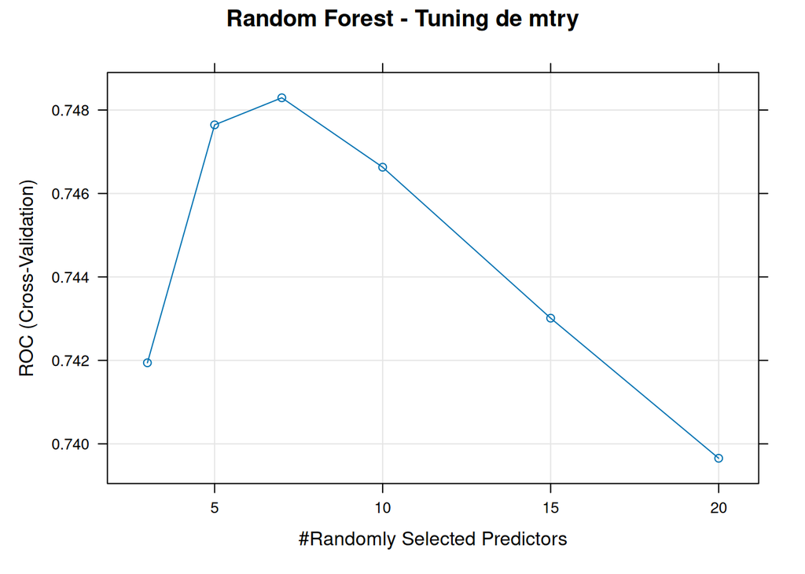

Figure 1: Performance de la forêt aléatoire selon mtry

```r
plot(model_rf, main = "Random Forest - Tuning de mtry")
```

## Importance des variables

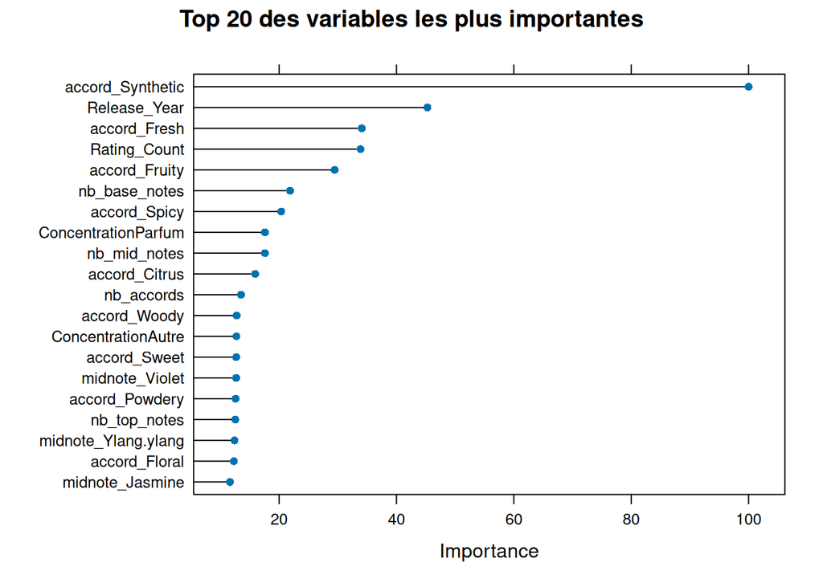

Figure 2: Importance des variables (Random Forest)

```r
var_imp <- varImp(model_rf)
plot(var_imp, top = 20, main = "Top 20 des variables les plus importantes")
```

**AstuceInterprétation**

Le classement de l’importance des variables permet d’identifier quelles caractéristiques des parfums (accords, notes, concentration) influencent le plus la satisfaction des utilisateurs.

## Évaluation sur le jeu de test

```r
pred_rf <- predict(model_rf, test_data)
prob_rf <- predict(model_rf, test_data, type = "prob")

cm_rf <- confusionMatrix(pred_rf, test_data$Satisfaction, positive = "Oui")
print(cm_rf)
```

```
Confusion Matrix and Statistics

          Reference
Prediction  Non  Oui
       Non 2520 1104
       Oui 1594 3795

               Accuracy : 0.7007
                 95% CI : (0.6911, 0.7101)
    No Information Rate : 0.5435
    P-Value [Acc > NIR] : < 2.2e-16

                  Kappa : 0.3909

 Mcnemar's Test P-Value : < 2.2e-16

            Sensitivity : 0.7746
            Specificity : 0.6125
         Pos Pred Value : 0.7042
         Neg Pred Value : 0.6954
             Prevalence : 0.5435
         Detection Rate : 0.4211
   Detection Prevalence : 0.5979
      Balanced Accuracy : 0.6936

       'Positive' Class : Oui
```

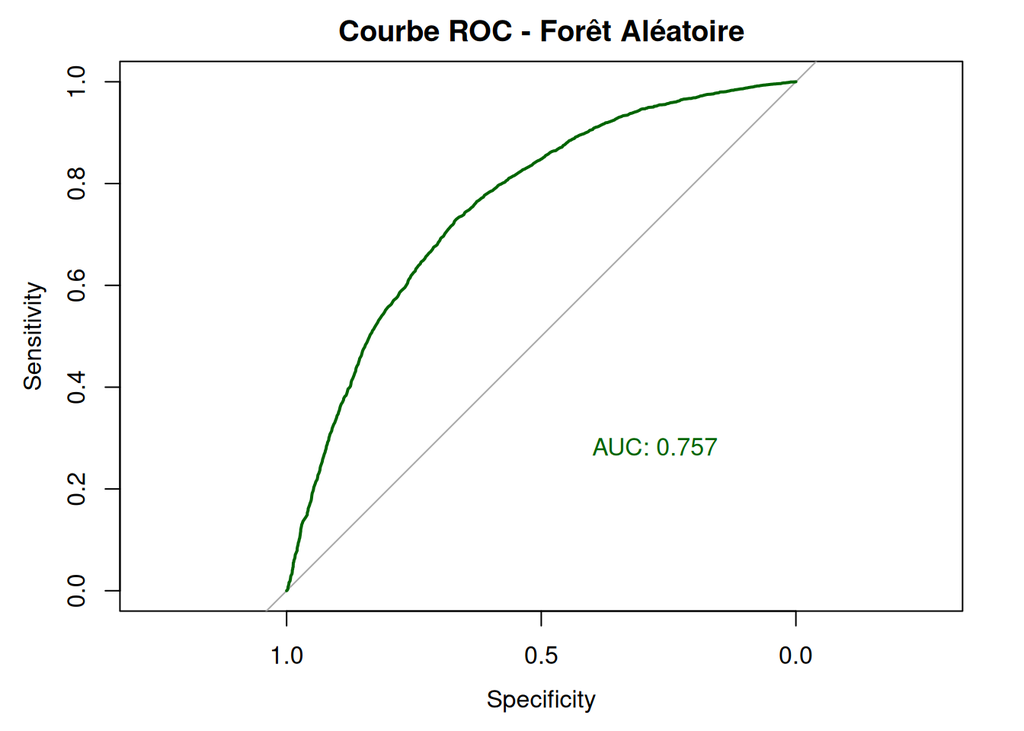

Figure 3: Courbe ROC – Forêt Aléatoire

```r
roc_rf <- roc(test_data$Satisfaction, prob_rf$Oui)

plot(roc_rf, col = "darkgreen", main = "Courbe ROC - Forêt Aléatoire",
     print.auc = TRUE, print.auc.x = 0.4, print.auc.y = 0.3)
```

# Sauvegarde

```r
saveRDS(model_rf, here::here("output", "model_rf.rds"))
saveRDS(cm_rf, here::here("output", "cm_rf.rds"))
saveRDS(roc_rf, here::here("output", "roc_rf.rds"))
cat("Modèle et résultats sauvegardés dans output/\n")
```

```
Modèle et résultats sauvegardés dans output/
```

## Les références

Breiman, Leo. 2001. « Random Forests ». *Machine Learning* 45 (1): 5‑32.